# Laboratório de Análise de Redes Sociais (ARS) — Gabarito com R

PPG-PP — UFABC

26 August 2025

## Pacotes

> Observação: `igraph` é essencial. `tidygraph`/`ggraph` e `tidyverse` facilitam tabelas e gráficos. Se algum pacote não estiver instalado, descomente a linha `install.packages()`.

```r
# install.packages(c("igraph","tidygraph","ggraph","tidyverse","knitr","kableExtra","patchwork"))
library(igraph)
library(tidygraph)
library(ggraph)
library(tidyverse)
library(knitr)
library(kableExtra)
library(patchwork)   # para combinar gráficos com operador |
```

## Funções auxiliares

```r
# Z-score seguro (retorna numérico simples)
zscore <- function(x) as.numeric(scale(x))

# Tabela bonita
kbl2 <- function(df, caption = NULL){
  kbl(df, caption = caption, digits = 3) |>
    kable_styling(full_width = FALSE, bootstrap_options = c("striped","hover"))
}

# Resumo global de uma rede (direcionada ou não)
resumo_rede <- function(g){
  tibble(
    nos = gorder(g),
    arestas = gsize(g),
    componentes = components(g)$no,
    densidade = edge_density(g, loops = FALSE),
    diametro = suppressWarnings(diameter(g, directed = is_directed(g), weights = NA)), # sem pesos
    dist_media = suppressWarnings(mean_distance(g, directed = is_directed(g)))
  )
}

# Ranking helper
ranking <- function(vec, n = 5, nome = "valor"){
  tibble(no = names(vec), !!nome := as.numeric(vec)) |>
    arrange(desc(.data[[nome]])) |>
    slice_head(n = n)
}
```

# Exercício 1 — Rede básica e métricas descritivas

**Objetivo.** Familiaridade com objetos de rede e medidas globais.

**Dados.** Rede Erdős–Rényi (1-modo), ~40 nós, probabilidade de ligação baixa (0,05–0,08).

```r
# Simulação ER (G(n,p))
n1 <- 40
p1 <- 0.07
g1 <- sample_gnp(n = n1, p = p1, directed = FALSE, loops = FALSE)

# Métricas globais
tab1 <- resumo_rede(g1)
kbl2(tab1, caption = "Exercício 1 — Métricas globais (ER)")
```

Exercício 1 — Métricas globais (ER)

| nos | arestas | componentes | densidade | diametro | dist_media |
| --- | --- | --- | --- | --- | --- |
| 40 | 62 | 3 | 0.079 | 8 | 3.243 |

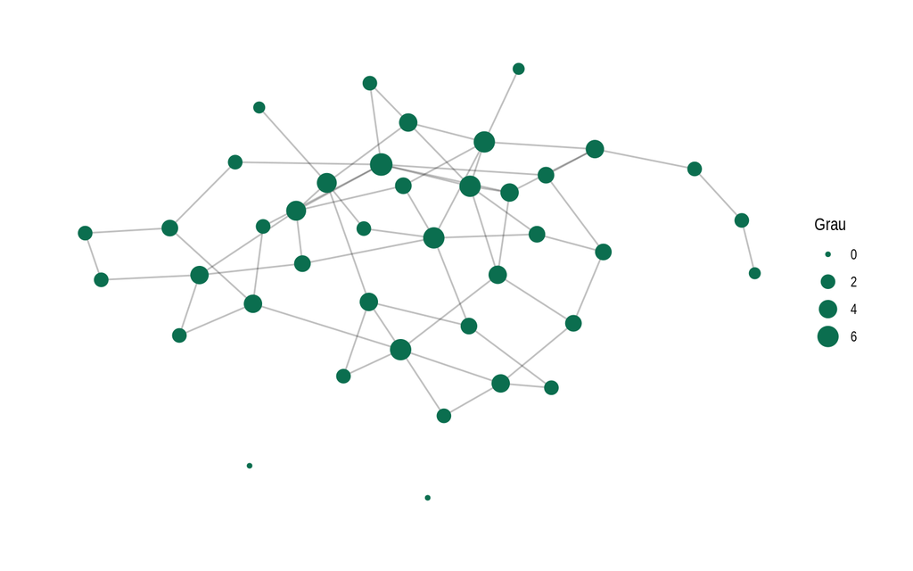

```r
# Tamanho do nó proporcional ao grau
deg1 <- degree(g1)
ggraph(g1, layout = "fr") +
  geom_edge_link(alpha = .25) +
  geom_node_point(aes(size = deg1), color = "#0B6E4F") +
  scale_size_continuous(name = "Grau") +
  theme_graph()
```

**Interpretação.**  
Densidade baixa sugere **difusão mais lenta** e maior distância média; o diâmetro indica o pior caso de alcance. O desenho ER produz heterogeneidade limitada de graus, então **hubs** marcantes não devem aparecer.

# Exercício 2 — Três topologias: aleatória, small-world e scale-free

**Objetivo.** Comparar estruturas com impacto em difusão e resiliência.

```r
n2 <- 80

# (a) Aleatória ER
p2 <- 0.04
g2_er <- sample_gnp(n = n2, p = p2)

# (b) Small-world (Watts-Strogatz): anel k vizinhos, prob. de rewire
dim <- 1; nei <- 4; p_rewire <- 0.05
g2_sw <- sample_smallworld(dim = dim, size = n2, nei = nei, p = p_rewire)

# (c) Scale-free (Barabási-Albert)
m <- 2  # novas arestas por nó
g2_sf <- sample_pa(n = n2, power = 1, m = m, directed = FALSE)

# Métricas comparativas
cmp <- bind_rows(
  resumo_rede(g2_er) |> mutate(rede = "ER"),
  resumo_rede(g2_sw) |> mutate(rede = "Small-world"),
  resumo_rede(g2_sf) |> mutate(rede = "Scale-free")
) |>
  relocate(rede)

kbl2(cmp, caption = "Exercício 2 — Comparação de métricas globais")
```

Exercício 2 — Comparação de métricas globais

| rede | nos | arestas | componentes | densidade | diametro | dist_media |
| --- | --- | --- | --- | --- | --- | --- |
| ER | 80 | 110 | 6 | 0.035 | 9 | 4.060 |
| Small-world | 80 | 320 | 1 | 0.101 | 5 | 2.834 |
| Scale-free | 80 | 157 | 1 | 0.050 | 6 | 3.037 |

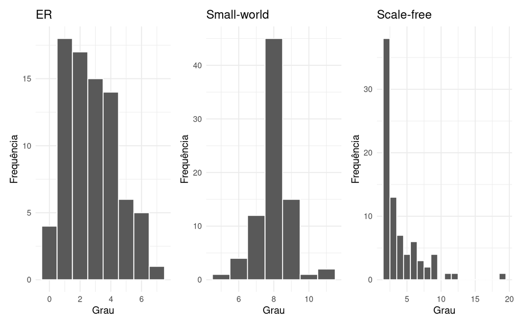

```r
# Distribuição de grau para cada rede
plot_degree <- function(g, titulo){
  dg <- degree(g)
  tibble(grau = dg) |>
    ggplot(aes(grau)) + geom_histogram(binwidth = 1, color = "white") +
    labs(title = titulo, x = "Grau", y = "Frequência") +
    theme_minimal()
}
plot_degree(g2_er, "ER") |
  plot_degree(g2_sw, "Small-world") |
  plot_degree(g2_sf, "Scale-free")
```

**Interpretação.**  
Small-world tende a **alta clusterização** com **caminhos curtos**; ER serve de referência; scale-free exibe **cauda pesada de graus** (hubs). Difusão costuma ser rápida em **small-world** e **scale-free**, mas a última é **frágil** a falhas direcionadas em hubs.

# Exercício 3 — Centralidades: grau, betweenness, closeness, autovetor

**Objetivo.** Diferenciar papéis na rede small-world.

```r
g <- g2_sw
deg  <- degree(g)
bet  <- betweenness(g, directed = FALSE)
clo  <- closeness(g, normalized = TRUE)
eig  <- eigen_centrality(g)$vector

tab_deg <- ranking(deg, 5, "grau")
tab_bet <- ranking(bet, 5, "betweenness")
tab_clo <- ranking(clo, 5, "closeness")
tab_eig <- ranking(eig, 5, "eigenvector")

kbl2(tab_deg, caption = "Top-5 — Grau")
```

Top-5 — Grau

| grau |
| --- |
| 11 |
| 11 |
| 10 |
| 9 |
| 9 |

```r
kbl2(tab_bet, caption = "Top-5 — Betweenness")
```

Top-5 — Betweenness

| betweenness |
| --- |
| 342.063 |
| 266.825 |
| 218.473 |
| 208.433 |
| 197.338 |

```r
kbl2(tab_clo, caption = "Top-5 — Closeness")
```

Top-5 — Closeness

| closeness |
| --- |
| 0.416 |
| 0.409 |
| 0.409 |
| 0.397 |
| 0.395 |

```r
kbl2(tab_eig, caption = "Top-5 — Autovetor (prestígio por associação)")
```

Top-5 — Autovetor (prestígio por associação)

| eigenvector |
| --- |
| 1.000 |
| 0.979 |
| 0.958 |
| 0.951 |
| 0.931 |

**Interpretação.**  
• **Grau** ≈ acesso imediato. • **Betweenness** identifica **corretores/gargalos**. • **Closeness** mede **alcance rápido**. • **Autovetor** detecta **prestígio estrutural** por associação com nós centrais. Os quatro rankings **não** precisam coincidir.

# Exercício 4 — Tríades, fechamento e comunidades

**Objetivo.** Relacionar microestrutura e módulos.

```r
# Escolha uma rede (usamos small-world)
g <- g2_sw

# Transitividade/fechamento triádico (global)
trans <- transitivity(g, type = "global")

# Comunidades (Louvain) — requer grafo não direcionado e pesos >= 0
com <- cluster_louvain(g)
mod <- modularity(g, membership = membership(com))

tibble(
  transitividade = trans,
  comunidades = length(unique(membership(com))),
  modularidade = mod
) |> kbl2("Exercício 4 — Tríades e comunidades (Louvain)")
```

Exercício 4 — Tríades e comunidades (Louvain)

| transitividade | comunidades | modularidade |
| --- | --- | --- |
| 0.48 | 5 | 0.587 |

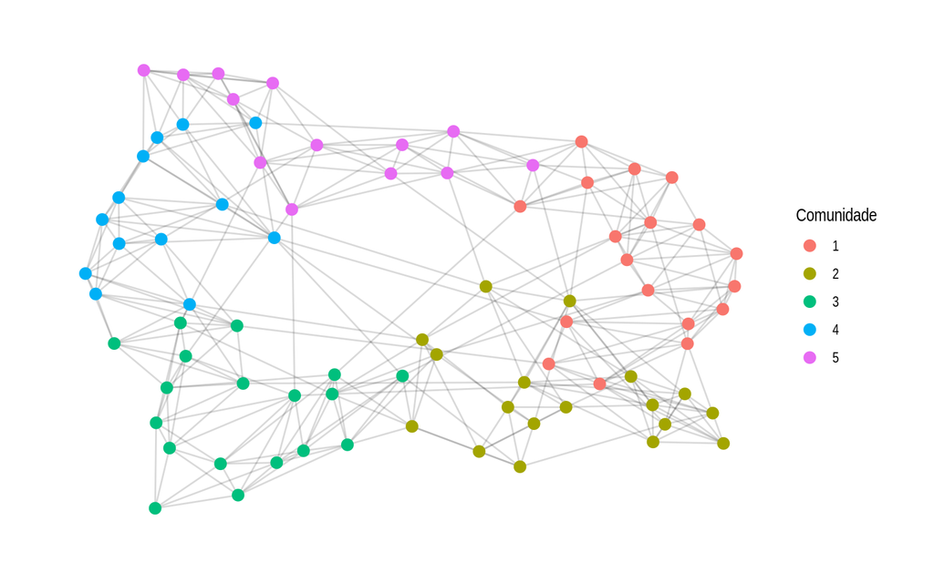

```r
# Visual: cores por comunidade
V(g)$com <- factor(membership(com))
ggraph(g, layout = "fr") +
  geom_edge_link(alpha = .15) +
  geom_node_point(aes(color = com), size = 3) +
  theme_graph() + guides(color = guide_legend(title = "Comunidade"))
```

**Interpretação.**  
Transitividade alta sugere **fechamento triádico** (confiança/monitoramento local). Modularidade alta indica **silos/coalizões**; a política pode **criar pontes** para reduzir distância média entre comunidades.

# Exercício 5 — Atributos e homofilia

**Objetivo.** Medir assortatividade por **setor** e **nível**.

```r
set.seed(321)
g <- g2_sw
# Atributos simulados
sector_vals <- c("Saúde","Educação","Assistência")
level_vals  <- c("Municipal","Estadual")

V(g)$setor <- sample(sector_vals, gorder(g), replace = TRUE, prob = c(.4,.35,.25))
V(g)$nivel <- sample(level_vals,  gorder(g), replace = TRUE, prob = c(.7,.3))

# Assortatividade nominal requer vetor numérico de categorias
assort_setor <- assortativity_nominal(g, as.integer(factor(V(g)$setor)), directed = FALSE)
assort_nivel <- assortativity_nominal(g, as.integer(factor(V(g)$nivel)), directed = FALSE)

tibble(medida = c("Assortatividade (setor)","Assortatividade (nível)"),
       valor  = c(assort_setor, assort_nivel)) |>
  kbl2("Exercício 5 — Assortatividade")
```

Exercício 5 — Assortatividade

| medida | valor |
| --- | --- |
| Assortatividade (setor) | 0.033 |
| Assortatividade (nível) | -0.067 |

```r
# Tabelas de mistura (contagens por atributo nas arestas)
ends_mat <- ends(g, E(g))
mix_setor <- table(V(g)$setor[ends_mat[,1]], V(g)$setor[ends_mat[,2]])
mix_nivel <- table(V(g)$nivel[ends_mat[,1]], V(g)$nivel[ends_mat[,2]])

kbl2(as.data.frame.matrix(mix_setor), "Matriz de mistura por Setor (contagens de arestas)")
```

Matriz de mistura por Setor (contagens de arestas)

|  | Assistência | Educação | Saúde |
| --- | --- | --- | --- |
| Assistência | 21 | 28 | 31 |
| Educação | 31 | 46 | 42 |
| Saúde | 20 | 50 | 51 |

```r
kbl2(as.data.frame.matrix(mix_nivel), "Matriz de mistura por Nível (contagens de arestas)")
```

Matriz de mistura por Nível (contagens de arestas)

|  | Estadual | Municipal |
| --- | --- | --- |
| Estadual | 16 | 64 |
| Municipal | 64 | 176 |

**Interpretação.**  
Valores positivos sugerem **homofilia** (ligações entre iguais). Se a meta é integração, procure **bridging** entre categorias distintas.